# Human capital and knowledge

**NOTE**: The present notebook is coded in R. It relies heavily on the [**tidyverse**](https://www.tidyverse.org/) ecosystem of packages. We load the tidyverse below as a prerequisite for the rest of the notebook - along with a few other libraries.

$\rightarrow$ Don’t forget that code flows **sequentially**. A random chunk may not work if the previous have have not been executed.

```r
library(tidyverse)     # Package for data wrangling
library(readxl)        # Package to import MS Excel files
library(latex2exp)     # Package for LaTeX expressions
library(quantmod)      # Package for stock data extraction
library(highcharter)   # Package for reactive plots
library(ggrepel)       # Better labels on plots
library(WDI)           # To access World Bank data
library(broom)         # Neat regression output
```

**NoteSide note**

The function below will be used to fill in **missing data points**, on a country-by-country basis (via grouping).  
We allow copy-pasting the most recent value up to a maximum of six years.  
This assumes some form of stability/persistence in the imputed variable.

```r
impute <- function(v){ # Imputation function
    n <- 6
    for(j in 1:n){
        ind <- which(is.na(v))
        if(length(ind) > 0){if(ind[1]==1) {ind <- ind[-1]}}
        v[ind] <- v[ind-1]
    }
    return(v)
}
```

The content of the notebook is heavily inspired from the book [**Advanced Macro-economics - An Easy Guide**](https://press.lse.ac.uk/site/books/m/10.31389/lsepress.ame/).

# Context & motivation

The models we have covered so far do not allow for strictly positive growth in equilibrium. There are several ways in which they can be changed in order to try to foster **endogenous growth**. One might be that we can include some human capital into the model and can expect that better health and education can improve productivity.

But first, let’s see if the [**Human Capital Index**](https://datacatalog.worldbank.org/search/dataset/0038030/human-capital-index) from the World Bank can explain cross-sectional variations in growth across countries.

```r
library(WDI)
wb_raw <- WDI(indicator = c("gdp_per_capita" = "NY.GDP.PCAP.KD",
                            "population" = "SP.POP.TOTL",
                            "gdp" = "NY.GDP.MKTP.CD",
                            "human_capital" = "HD.HCI.OVRL",
                            "gdp_growth" = "NY.GDP.MKTP.KD.ZG"),
              #country = c('FR','US'), # here you can specify some countries
              extra = TRUE,
              start = 1960,
              end = 2025) |>
  mutate(across(everything(), as.vector)) |>
  select(-status, -lending, -iso2c, -iso3c) |>
  filter(region != "Aggregates", income != "Aggregates") |>
  arrange(country, year) |>
  group_by(country) |>
  mutate(across(everything(), impute)) |>
  mutate(HC_change = human_capital/lag(human_capital) - 1) |>
  ungroup()
```

Checking if **imputation** has worked.

```r
wb_raw |>
  select(country, year, population, gdp, human_capital) |>
  tail(7)
```

[output not shown]

Population and GDP have been updated in the data, but human capital has not…

## In the cross-section

Now, let’s compute the average growth rate and GDP per capita of countries and plot them against **human capital**.  
**NOTE**: the data is relatively sparse and the last point is in 2020. But still…

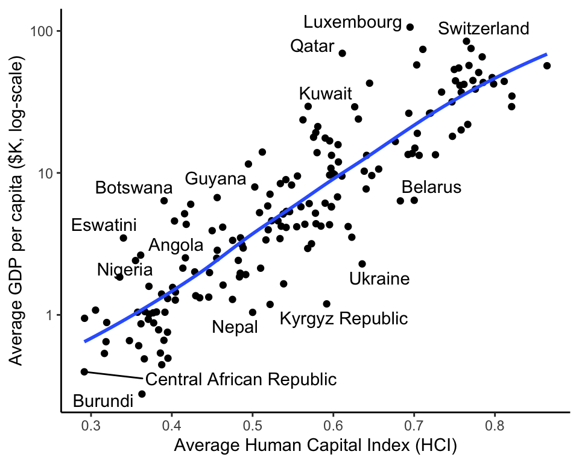

```r
wb_raw |>
  filter(is.finite(human_capital), ) |>
  group_by(country, region) |>
  summarise(avg_growth = mean(gdp_growth, na.rm = T),
            avg_wealth = mean(gdp_per_capita/1000, na.rm = T),
            avg_human_capital = mean(human_capital, na.rm = T)) |>
  ggplot(aes(x = avg_human_capital, y = avg_wealth)) + geom_point() +
  geom_smooth(se = F) + scale_y_log10() +
  theme_classic() + ylab("Average GDP per capita ($K, log-scale)") + xlab("Average Human Capital Index (HCI)") +
  geom_text_repel(aes(label = country))
```

The relationship is this case is pretty clear.

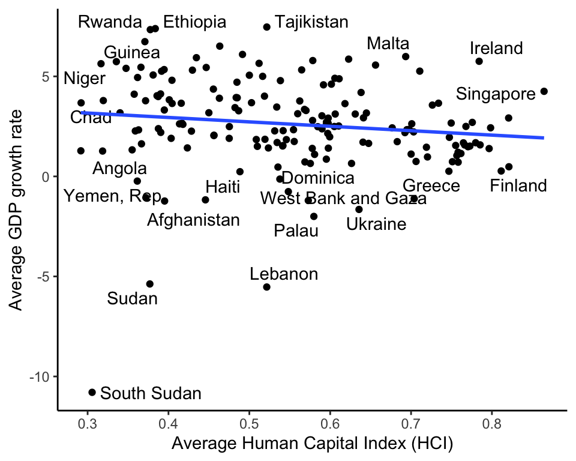

```r
wb_raw |>
  filter(is.finite(human_capital)) |>
  group_by(country) |>
  summarise(avg_growth = mean(gdp_growth, na.rm = T),
            avg_wealth = mean(gdp_per_capita, na.rm = T),
            avg_human_capital = mean(human_capital, na.rm = T)) |>
  filter(avg_growth < 10) |>
  ggplot(aes(x = avg_human_capital, y = avg_growth)) + geom_point() +
  theme_classic() + ylab("Average GDP growth rate") + xlab("Average Human Capital Index (HCI)") +
  geom_text_repel(aes(label = country)) + geom_smooth(se = F, method = "lm")
```

Things are much less clear for **economic growth**…

## Time-series

```r
lm(gdp_growth ~ lag(human_capital), data = wb_raw |> filter(country == "United States")) |> broom::tidy()
```

| term | estimate | std.error | statistic | p.value |
| --- | --- | --- | --- | --- |
| (Intercept) | -0.2933042 | 9.653291 | -0.0303839 | 0.9760349 |
| lag(human_capital) | 3.8652608 | 13.722084 | 0.2816818 | 0.7808202 |

The link (as measured through the $t$-statistics), is weak.

We could also investigate the link between growth and **change** in human capital. Indeed, there is a problem in the above model: the **independent variable** (human capital) is **persistent**. Given the fact that the regression is [**predictive**](https://www.sciencedirect.com/science/article/pii/S0304405X99000410), this causes **autocorrelation in residuals** and thus perturbs inference (the standard errors are under-estimated).

One “simple” solution to this is to instead consider **variations** in human capital (when it improves or deteriorates and the effect this has on future economic output).

```r
lm(gdp_growth ~ lag(HC_change), data = wb_raw |> filter(country == "United States")) |> broom::tidy()
```

| term | estimate | std.error | statistic | p.value |
| --- | --- | --- | --- | --- |
| (Intercept) | 2.448426 | 0.3023969 | 8.0967321 | 0.0000001 |
| lag(HC_change) | 10.271897 | 21.6312544 | 0.4748637 | 0.6400285 |

The results is not really more compelling.

Let us nonetheless turn to some theory!

# The model

## Production

In this section, the change comes from the **production function**:

$$Y = K^\alpha H^\beta (AL)^\gamma,$$

where $H$ stands for **human capital** and returns to scale are constant, increasing or decreasing if $\alpha+\beta+\gamma$ is equal to one, strictly above, or strictly below. The productivity (or technological) factor $A$ is associated to labor in this case. Dividing by $L$ under CRS, we get the per-capita version:

$$y = A^\gamma k^\alpha h^\beta , \tag{1}$$

## Evolution through saving & depreciation

As in the simpler models (e.g., à la Solow), we assume savings rates for physical and human capital $s_k$ and $s_h$; as well as depreciation rates, too: $\delta_k$ and $\delta_h$.

**NoteSide note**

Whether human capital depreciates could be open to debate…  
Schools, research labs, yes; but if we think of worker experience, then less so.

Then, time-variations are given by

$$\dot{K} = s_kY-\delta_k K \quad \Leftrightarrow \quad \frac{\dot{K}}{L}=s_ky-\delta_kk$$
$$\dot{H} = s_hY-\delta_h H \quad \Leftrightarrow \quad \frac{\dot{H}}{L}=s_hy-\delta_hh.$$
Moreover, by definition, $\dot{k}=\dot{K}/L-nk$ and $\dot{h}=\dot{H}/L-nh$, where $n$ is the constant growth rate of the population $(L)$. Plugging this into the above expressions, we get
$$\dot{k}=s_k A^\gamma k^\alpha h^\beta-(\delta_k+n)k, \quad \text{and} \quad \dot{h}=s_h A^\gamma k^\alpha h^\beta-(\delta_h+n)h,$$
and the corresponding **relative growth rates** are:
$$\gamma_k=\frac{\dot{k}}{k}=s_k A^\gamma k^{\alpha-1} h^\beta-(\delta_k+n)$$
$$\gamma_h=\frac{\dot{h}}{h}=s_h A^\gamma k^{\alpha} h^{\beta-1}-(\delta_h+n).$$

## Steady states

The balanced growth path requires that $\gamma_k$ and $\gamma_h$ be constant. Since $\delta_k+n$ and $\delta_h+n$ are already constant, we need that $s_k A^\gamma k^{\alpha-1} h^\beta$ and $s_h A^\gamma k^{\alpha} h^{\beta-1}$ be constant. To simplify these quantities, we take their log (they, too, have to be constant), and we differentiate with respect to time (log($s_k$), log($A^\gamma$), and log($s_h$) are constant so they vanish):
$$\frac{\partial}{\partial t} \left((\alpha-1) \log(k)+\beta \log(h) \right)=(\alpha-1) \frac{\dot{k}}{k}+\beta \frac{\dot{h}}{h}=(\alpha-1)\gamma_k+\beta \gamma_h=0$$
$$\frac{\partial}{\partial t} \left(\alpha \log(k)+(\beta-1) \log(h) \right)=\alpha \frac{\dot{k}}{k}+(\beta-1) \frac{\dot{h}}{h}=\alpha\gamma_k+(\beta-1) \gamma_h=0.$$
Both l.h.s. expressions have to be equal to zero, i.e, from the second equation, $\gamma_h=\frac{\alpha}{1-\beta}\gamma_k$ and substituting this into the first equation,
$$\left((\alpha-1)+\frac{\beta \alpha}{1-\beta}\right) \gamma_k=\frac{(\alpha-1)(1-\beta)+\alpha \beta}{1-\beta}\gamma_k=\frac{\alpha+\beta-1}{1-\beta} \gamma_k=0.$$
If we assume **constant returns to scale**, $\alpha+\beta < 1$ (because else $\gamma=0$ and in this case, labor and productivity are out of the game, which is not what we want!). And obviously, $\beta > 0$ for the same reason (human capital), hence this imposes $\gamma_k=0$.

**Important**

Again, this means **zero growth in equilibrium**!

We are not really more advanced - but this was to be expected because the model is too Solow-like (the basic mechanisms are the same).

## Another model

This section follows Barro and Sala-ì-Martin, Section 5.1.  
The production is of **Cobb-Douglas** type:

$$Y=AK^aH^{1-a}, \quad a \in (0,1),$$
with $H$ being **human capital**. The resource constraint is:
$$Y=C+I_K+I_H,$$
where $I_K$ and $I_H$ are the investments in capital and in the workforce. Importantly, consumption remains the only **control variable**, while investments are **state variables**. Moreover,
$$\dot{K}=I_K-\delta_KK, \quad \dot{H}=I_H-\delta_HH.$$

The population seeks to maximize utility across generations: $\int_0^\infty e^{-\rho t}u(C_t)dt$.
Given the 3 constraints listed above, the **Hamiltonian** is
$$J=e^{-\rho t}u(C)+\nu(I_K-\delta_KK)+\mu(I_H-\delta_HH)+\omega(AK^aH^{1-a}-C-I_K-I_H).$$

The model then assumes a CRRA utility function, written as $u(x)=x^{1-\theta}/(1-\theta)$. We have

$$\frac{\partial J}{\partial C}=e^{-\rho t}C^{-\theta} -\omega, \quad \frac{\partial J}{\partial I_K}=\nu -\omega, \quad \frac{\partial J}{\partial I_H}=\mu -\omega$$
and setting all these expressions to zero, we get
$$\omega = \nu = \mu = e^{-\rho t}C^{-\theta}.$$
Hence, differentiating with respect to *t*, we obtain (equating with $\partial J/\partial K$ and $\partial J/\partial H$ because of the **FOC for state variables**),

$$\dot{\nu}=-\rho e^{-\rho t}C^{-\theta}-\theta e^{-\rho t}C^{-\theta-1} \dot{C}=\frac{\partial J}{\partial K}=\nu \delta_K-\omega a A K^{a-1}H^{1-a}$$

$$\dot{\mu}=-\rho e^{-\rho t}C^{-\theta}-\theta e^{-\rho t}C^{-\theta-1} \dot{C}=\frac{\partial J}{\partial H}=-\mu \delta_H-\omega (1-a) A K^{a}H^{-a}$$

And since $\omega = \nu=\mu$, it must hold that
$$\frac{\dot{\nu}}{\nu}=\delta_K-aAK^{a-1}H^{1-a}, \quad \frac{\dot{\mu}}{\mu}=-\delta_H+(1-a)AK^{a}H^{-a}.$$
At the same time, from the expressions of $\dot{\nu}$ and $\dot{\mu}$, we derive
$$\frac{\dot{\nu}}{\nu}=-\rho -\theta \frac{\dot{C}}{C}, \quad \frac{\dot{\mu}}{\mu}=-\rho -\theta \frac{\dot{C}}{C}.$$

Hence,

$$\frac{\dot{C}}{C}=\theta^{-1}(Aa^a(1-a)^{1-a}-\delta-\rho)$$

If $Y=AK^aH^{1-a}= AK (K/H)^{a-1}$ and Equation 3 holds, we have
$$Y=AK\left(\frac{a}{1-a} \right)^{a-1}.$$
$\rightarrow$ The *AK* model! More on that soon.

If $\delta_H \neq \delta_K$,

$$aA(K/H)^{a-1}-\delta_K=(a-1)A(K/H)^{a}-\delta_H,$$
and $K/H$ does not have a simple expression (when end up with an algebraic equation).

# Two imperfect avenues towards growth

## Returns to scale

One reason why growth is not possible in the extended Solow model is the assumption of **constant returns to scale**. Indeed, if we allow $\alpha+\beta=1$ (and $\gamma >0$, so that **total** returns to scale are increasing), then $\gamma_k \neq 0$. Ok, but that’s an easy one.

And, in practice, at the aggregate level, returns seem to be close to, or slightly smaller than, **one** (but with **sector heterogeneity**), see for instance:

- [Returns to Scale in U.S. Production: Estimates and Implications](https://www.journals.uchicago.edu/doi/abs/10.1086/262073)
- [On the estimation of returns to scale, technical progress and monopolistic markups](https://www.sciencedirect.com/science/article/abs/pii/S0304407608000584)
- [On estimating optimal α-returns to scale](https://www.tandfonline.com/doi/abs/10.1080/01605682.2017.1418148)

## Exogenous growth

If $\gamma_k= s_k y/k-(\delta_k+n)$ and $\gamma_h=s_h y/h-(\delta_h+n)$ are constant, then $k/y$ and $h/y$ are constant and all variables grow at the same pace. Let’s take log-output:

$$\log(y)=\gamma \log(A) + \alpha \log(k) +\beta \log(h),$$

hence, differentiating with respect to time (recalling a Cobb-Douglas function $y=A^\gamma k^\alpha h^\beta$),
$$\frac{\dot{y}}{y} = \gamma \frac{\dot{A}}{A}+\alpha \frac{\dot{k}}{k} + \beta \frac{\dot{h}}{h}$$

Since $x = \frac{\dot{y}}{y} =\frac{\dot{k}}{k} = \frac{\dot{h}}{h}$, if we write $g$ for the relative growth rate of $A$ we get
$$x = \gamma g + \alpha x + \beta x,$$
and assuming constant returns to scale $1-\alpha-\beta=\gamma$, we get $x=g$, i.e., all growth rates are equal to $g$, the rate of increase of the productivity factor $A$. But this is not **endogenous** growth…

# The AK model

## Assumptions and BGP

**NoteThis is a special model because it assumes**

$$y=Ak,$$
hence its name.

As in the **Ramsey model**, if we assume $n=0$, capital evolves as:
$$\dot{k}_t=y_t-c_t=Ak_t-c_t. \tag{4}$$

We then set the **utility function**:
$$u(c_t)=\left(\frac{\sigma}{\sigma-1} \right)c_t^{(\sigma-1)/\sigma},$$
which implies $u'(c_t)=c_t^{-1/\sigma}$ and $u''(c_t)=-\sigma^{-1}c_t^{-1-1/\sigma}$ so that indeed $-\frac{u'(c)}{u''(c)c}=\sigma$.

As before, the representative agent seeks to maximize **discounted utility** over an infinite horizon: $\int_0^\infty u(c_t)e^{-\rho t}dt$.

The corresponding **Hamiltonian** is
$$H=\left( \frac{\sigma}{\sigma - 1} \right)c_t^{(\sigma-1)/\sigma}+\lambda_t (A k_t - c_t),$$
leading to

$$\frac{\partial H}{\partial c_t}=c_t^{-1/\sigma}-\lambda_t=0$$
and, for the **co-state** variable, to
$$\dot{\lambda}_t=-\frac{\partial H}{\partial k_t}+\rho \lambda_t=(\rho-A)\lambda_t.$$

The first FOC implies $\lambda_t=c_t^{-1/\sigma}$, hence $\dot{\lambda}_t=-\sigma^{-1}c_t^{-1-1/\sigma} \dot{c}_t$. If we divide this by the FOC, we get

$$\frac{\dot{\lambda}_t}{\lambda_t}=-\sigma^{-1} \frac{\dot{c}_t}{c_t}$$

From the second FOC, this implies
$$\frac{\dot{c}_t}{c_t}=\sigma(A-\rho). \tag{5}$$

Hence, consumption is exactly **proportional** to capital (and output).

## The transversality condition

In the model, the TVC $e^{-\rho t}k_t \lambda_t \rightarrow 0$ is $e^{-\rho t}k_t c^{-\sigma^{-1}_t} \rightarrow 0$. The differential Equation 5 has simple solution $c_t=c_0e^{(\sigma(A-\rho))t}$. But remember that this is also true for $k$: $k_t=k_0 e^{(\sigma(A-\rho))t}$, hence the condition becomes $k_0c_0^{-\sigma^{-1}}e^{(\sigma(A-\rho)-A)t}\rightarrow 0$, which requires $\sigma(A-\rho)<A$.

## Simulations

TO DO !! (in class?)

# Knowledge & learning by doing

To generate growth, one way may be to rely on some form **productivity**. From a **human capital** perspective, the idea here is to assume that **experience** gets workers better at **production**. Below, we follow the survey [*Learning by doing*](https://digitalcommons.fiu.edu/economics_wps/42/), Section 5. See also [On the mechanics of economic development](https://www.sciencedirect.com/science/article/abs/pii/0304393288901687) by Lucas, wherein **technology** is put forward as driver of **human capital** (good transition with the next session!).

$$Y=AK^aL^{1-a},$$
with $A$ being **knowledge**. Labor increases as usual **exogenously** at rate $n$, while $K$ satisfies $\dot{K}=sY$, i.e., via savings and without depreciation. **Knowledge** is linked to cumulative investment (e.g., R&D) via $A=bK^\lambda$.

We simplify the production function to

$$y=Ak^a \tag{7}$$

and laws of motion are (same as in the Solow model below):

$$\frac{\dot{k}}{k}=sAk^{a-1}-n \tag{8}$$

and
$$\frac{\dot{A}}{A}=\lambda n+\lambda \frac{\dot{k}}{k}. \tag{9}$$

Indeed, $\dot{A}=b\lambda K^{\lambda-1}\dot{K}=\lambda A \frac{\dot{K}}{K}=\lambda A(\dot{k}/k+n)$ where the final equality comes from $\dot{K}/K=sY/K=sA(L/K)^{1-a}=sAk^{a-1}=\dot{k}/k+n$ (from Equation 8).

This implies

$$\frac{\dot{y}}{y}=\frac{\dot{A}k^a+Aa k^{a-1}\dot{k}}{Ak^a}=\frac{\dot{A}}{A}+a\frac{\dot{k}}{k}=\lambda n+(\lambda +a)(sAk^{a-1}-n).$$
In short, we have $\frac{\dot{y}}{y}=\lambda n+ (\lambda+a)\frac{\dot{k}}{k}$: output growth is an **affine function** of capital growth. If we assume $\frac{\dot{k}}{k}=0$, then growth comes from learning only if $n>0$. We can find a situation where all growth rates are positive. It corresponds to $\frac{\dot{y}}{y}=\frac{\dot{k}}{k}$ and $\frac{\dot{A}}{A}=(1-a)\frac{\dot{k}}{k}$. This yields
$$\frac{\dot{k}}{k}=\frac{\dot{y}}{y}=\frac{\lambda n}{1-a-\lambda}$$
Note that $n=0$ requires $a+\lambda=1$ (constant returns to scale) to obtain nonzero growth. If population grows, then it must hold that $a+\lambda<1$ (DRS).

**NOTE**: a simple alternative model can be found in *Economic Growth*, by Barro and Sala-i-Martin, Section 4.3.

**Note**

In the models above, production depends on **human capital** or **knowledge**.  
But the reverse causal relationship my also hold (output $\rightarrow$ human capital)…